# Data Analysis on Stack overflow survey

I used CRISDM appoarch In which following points are considered 1 Business understanding: outline the questions you will answer along with why they are relevant and important 2 Data understanding: provide some stats about your data like mean and std deviations of the different features 3 Data preparation: show how you clean and prepare the data. It is important to document and not just write the code 4 Data modeling: if you created a model this is the section you would put it in or the analysis 5 Results evaluation: conclusion and discussion

Business Understanding:These question are related to Bootcamp,Data Scientist and lifestyle of developers I try to figure out the relations between the attributes and and explain the importance in my result at end of evrey question

Data understanding :I tried to explain stats by showing their no. in data set and Probabiltiy and calculate some ratio for comparison like I tried to start with Gender who takes survey

Data perpartion : Data is prepared by cleaning and I tried to removing missing value and try to clean data and make more precise for calculations

Data modeling: I did'nt use any machine leanring model because my question are can be complete by Data analysis

Result evalution : I had concluded all the result in my blog You can check here https://medium.com/@dheerajmitra18/data-scientist-and-remote-developer-627ccc06850d

```python
import numpy as np
import pandas as pd
import matplotlib.pyplot as plt
import ALookAtTheData as t
%matplotlib inline

df = pd.read_csv('./survey_results_public.csv')
df.head()
```

|  | Respondent | Professional | ProgramHobby | Country | University | EmploymentStatus | FormalEducation | MajorUndergrad | HomeRemote | CompanySize | ... | StackOverflowMakeMoney | Gender | HighestEducationParents | Race | SurveyLong | QuestionsInteresting | QuestionsConfusing | InterestedAnswers | Salary | ExpectedSalary |
| --- | --- | --- | --- | --- | --- | --- | --- | --- | --- | --- | --- | --- | --- | --- | --- | --- | --- | --- | --- | --- | --- |
| 0 | 1 | Student | Yes, both | United States | No | Not employed, and not looking for work | Secondary school | NaN | NaN | NaN | ... | Strongly disagree | Male | High school | White or of European descent | Strongly disagree | Strongly agree | Disagree | Strongly agree | NaN | NaN |
| 1 | 2 | Student | Yes, both | United Kingdom | Yes, full-time | Employed part-time | Some college/university study without earning ... | Computer science or software engineering | More than half, but not all, the time | 20 to 99 employees | ... | Strongly disagree | Male | A master's degree | White or of European descent | Somewhat agree | Somewhat agree | Disagree | Strongly agree | NaN | 37500.0 |
| 2 | 3 | Professional developer | Yes, both | United Kingdom | No | Employed full-time | Bachelor's degree | Computer science or software engineering | Less than half the time, but at least one day ... | 10,000 or more employees | ... | Disagree | Male | A professional degree | White or of European descent | Somewhat agree | Agree | Disagree | Agree | 113750.0 | NaN |
| 3 | 4 | Professional non-developer who sometimes write... | Yes, both | United States | No | Employed full-time | Doctoral degree | A non-computer-focused engineering discipline | Less than half the time, but at least one day ... | 10,000 or more employees | ... | Disagree | Male | A doctoral degree | White or of European descent | Agree | Agree | Somewhat agree | Strongly agree | NaN | NaN |
| 4 | 5 | Professional developer | Yes, I program as a hobby | Switzerland | No | Employed full-time | Master's degree | Computer science or software engineering | Never | 10 to 19 employees | ... | NaN | NaN | NaN | NaN | NaN | NaN | NaN | NaN | NaN | NaN |

5 rows × 154 columns

Let start with how many male and female attend the survey

```python
df['Gender'].value_counts()
```

```
Male                                                       11664
Female                                                       970
Other                                                         73
Gender non-conforming                                         54
Male; Other                                                   42
Female; Transgender                                           28
Transgender                                                   20
Male; Gender non-conforming                                   19
Female; Gender non-conforming                                 11
Transgender; Gender non-conforming                             5
Male; Female                                                   5
Male; Transgender                                              4
Male; Female; Transgender; Gender non-conforming; Other        4
Female; Transgender; Gender non-conforming                     3
Male; Female; Transgender; Gender non-conforming               2
Male; Female; Transgender                                      2
Female; Other                                                  1
Male; Female; Gender non-conforming                            1
Gender non-conforming; Other                                   1
Male; Female; Other                                            1
Name: Gender, dtype: int64
```

# Q1 I want to know How bootcamps assisting with increasing diversity in tech careers and How Bootcamp helping Job and Developers?

```python
bootcamp_df=df[df['TimeAfterBootcamp'].isnull()==False]
nonbootcamp_df=df[df['TimeAfterBootcamp'].isnull()==True]
```

```python
bootcamp_df
```

[output not shown]

882 rows × 154 columns

```python
bootcamp_df['TimeAfterBootcamp'] = bootcamp_df['TimeAfterBootcamp'].fillna(0.0)
```

In above part I convert NaN values into 0 so jsut to make easy for your understanding

```python
bootcamp_df['TimeAfterBootcamp'].value_counts()/bootcamp_df.shape[0]
```

```
I already had a job as a developer when I started the program    0.479592
I got a job as a developer before completing the program         0.104308
One to three months                                              0.096372
Immediately upon graduating                                      0.095238
I haven't gotten a job as a developer yet                        0.072562
Less than a month                                                0.053288
Four to six months                                               0.035147
Six months to a year                                             0.032880
Longer than a year                                               0.030612
Name: TimeAfterBootcamp, dtype: float64
```

```python
bootcamp_df['Salary'].value_counts()
```

```
120000.000000    9
110000.000000    8
90000.000000     6
100000.000000    5
80000.000000     4
70000.000000     4
130000.000000    4
150000.000000    4
115000.000000    4
27956.989247     3
64516.129032     3
60000.000000     3
86021.505376     3
55000.000000     3
32258.064516     3
50000.000000     3
75000.000000     3
135000.000000    2
19108.280255     2
170000.000000    2
17618.558215     2
34408.602151     2
7341.065923      2
91397.849462     2
95000.000000     2
65000.000000     2
43750.000000     2
87331.536388     2
8809.279107      2
90909.090909     2
                ..
66666.666667     1
33333.333333     1
51000.000000     1
1431.297710      1
56561.085973     1
112903.225806    1
3234.501348      1
45801.526718     1
8064.516129      1
6606.959330      1
47800.000000     1
76500.000000     1
92500.000000     1
51515.151515     1
195000.000000    1
82000.000000     1
40645.161290     1
18148.695563     1
87000.000000     1
113750.000000    1
20537.634409     1
81136.363636     1
36129.032258     1
43870.967742     1
10762.331839     1
2580.645161      1
5160.000000      1
32500.000000     1
29520.430108     1
9600.000000      1
Name: Salary, Length: 200, dtype: int64
```

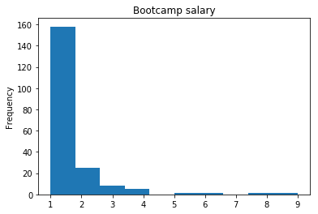

```python
bootcamp_df['Salary'].value_counts().plot(kind="hist");
plt.title("Bootcamp salary");
```

```python
def color_plot(data_frame,title_choose):
    """ This function is  used to crete a bar chart with different colors"""
    data_frame.plot(kind="bar");
    plt.title(title_choose);
```

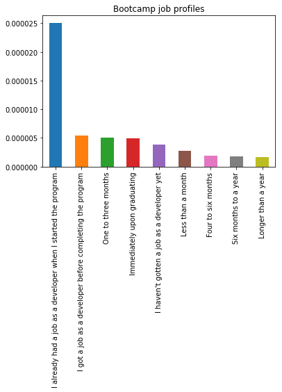

```python
job_profile=((bootcamp_df['TimeAfterBootcamp'].value_counts()/bootcamp_df.shape[0])/df.shape[0])
color_plot(job_profile,"Bootcamp job profiles")
```

# Q2 What type of Web Developrs take survey ,What is the gradution level of Data Scientist and what language they used ?

```python
web_devlopers=df['WebDeveloperType'].value_counts()
```

In this part we consider NaN value as 0 for Non categorical variable and note take part of our calculation and also We consider the value of categorical variable that are NaN are not part of our calculation

```python
web_devlopers
```

```
Full stack Web developer    2729
Back-end Web developer      1074
Front-end Web developer      483
Name: WebDeveloperType, dtype: int64
```

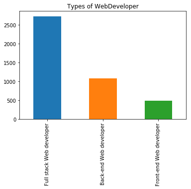

```python
color_plot(web_devlopers,"Types of WebDeveloper")
```

So they are mostly Full Stack Web Developer are in the market but what language full stack web developer used?

```python
web_dev=df[df['WebDeveloperType'].values=="Full stack Web developer"]
```

```python
web_dev['HaveWorkedLanguage'].value_counts()
```

```
C#; JavaScript; SQL                                           174
JavaScript; PHP; SQL                                          120
Java; JavaScript                                               78
Java; JavaScript; SQL                                          75
JavaScript; PHP                                                72
JavaScript                                                     66
C#; JavaScript                                                 65
C#; JavaScript; SQL; TypeScript                                62
JavaScript; Python                                             33
C#; JavaScript; TypeScript                                     30
JavaScript; PHP; Python; SQL                                   30
JavaScript; Ruby                                               26
C#                                                             19
Java; JavaScript; PHP; SQL                                     19
C#; JavaScript; PHP; SQL                                       18
C#; Java; JavaScript; SQL                                      18
Java; JavaScript; Python; SQL                                  18
JavaScript; Python; SQL                                        17
C#; JavaScript; SQL; VB.NET                                    16
JavaScript; SQL                                                16
Java                                                           16
C#; SQL                                                        15
Ruby                                                           14
CoffeeScript; JavaScript; Ruby                                 13
CoffeeScript; JavaScript; Ruby; SQL                            13
Java; JavaScript; PHP                                          13
JavaScript; PHP; SQL; TypeScript                               12
PHP                                                            12
JavaScript; Ruby; SQL                                          12
JavaScript; PHP; Ruby                                          12
                                                             ...
C#; JavaScript; TypeScript; VB.NET                              1
Java; JavaScript; Ruby; Visual Basic 6                          1
CoffeeScript; JavaScript; Ruby; Scala; TypeScript               1
JavaScript; PHP; SQL; VBA                                       1
C++; JavaScript; PHP; Ruby; SQL                                 1
C; C++; JavaScript; PHP; Python                                 1
C#; Java; Python; SQL                                           1
Dart; JavaScript; Python; SQL                                   1
C; C++; Groovy; Hack; Java; JavaScript; PHP; SQL                1
C#; JavaScript; PHP; Python; SQL                                1
Elixir; Go; JavaScript; PHP; Rust; SQL                          1
C#; Java; JavaScript; Matlab; TypeScript                        1
JavaScript; PHP; Smalltalk                                      1
CoffeeScript; Go; Java; JavaScript                              1
Elixir; JavaScript; PHP; Ruby; SQL                              1
Ruby; SQL                                                       1
C++; Groovy; Java; JavaScript; Python; SQL                      1
C++; JavaScript; PHP; Python; SQL; VB.NET                       1
Java; JavaScript; Scala; Swift                                  1
JavaScript; Ruby; Rust                                          1
CoffeeScript; JavaScript; Matlab; Python; Ruby; TypeScript      1
Java; Python; SQL; VB.NET                                       1
C; C++; Java; JavaScript; SQL; TypeScript                       1
CoffeeScript; JavaScript; Rust                                  1
Java; JavaScript; Perl; Python; Scala; SQL                      1
Java; JavaScript; Rust                                          1
C++; C#; Java; JavaScript; Lua; PHP; SQL                        1
C#; CoffeeScript; JavaScript; Python; SQL                       1
CoffeeScript; JavaScript; PHP; SQL; TypeScript                  1
C; Java                                                         1
Name: HaveWorkedLanguage, Length: 612, dtype: int64
```

```python
data_scientist=df[df['NonDeveloperType'].values=="Data scientist"]
```

```python
data_scientist['FormalEducation'].value_counts()/data_scientist.shape[0]
```

```
Bachelor's degree                                                    0.312057
Master's degree                                                      0.297872
Doctoral degree                                                      0.241135
Some college/university study without earning a bachelor's degree    0.085106
Secondary school                                                     0.028369
I prefer not to answer                                               0.021277
Professional degree                                                  0.014184
Name: FormalEducation, dtype: float64
```

```python
def blue_plot(data_frame,title_choose):
    """ This function is  used to crete a bar chart with same colors I choose blue color"""
    data_frame.plot(kind="bar",color='blue');
    plt.title(title_choose);
```

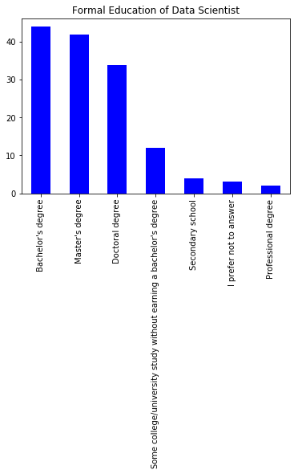

```python
educaton_ds = data_scientist['FormalEducation'].value_counts()
blue_plot(educaton_ds,"Formal Education of Data Scientist")
```

Now We can see person who are Data Scientist have Bachelors Degree and Master Degree and Bachelors are more means that they are not so much high qualification required to becom Data Scientist

```python
data_scientist['HaveWorkedLanguage'].value_counts()
```

```
Python; R; SQL                                                              7
Python; R                                                                   6
Python                                                                      6
R                                                                           6
C; C++; Python                                                              4
R; SQL                                                                      4
Matlab; Python                                                              3
Matlab; Python; R; SQL                                                      3
JavaScript; PHP; SQL                                                        2
Python; SQL                                                                 2
JavaScript; Python; SQL                                                     2
Python; SQL; VBA                                                            2
JavaScript; R                                                               2
C#; CoffeeScript; Haskell; Python                                           1
Assembly; C; C++; Java; JavaScript; Lua; Matlab; PHP; Python                1
C; C++; JavaScript; Lua; Python                                             1
C; Matlab; Python                                                           1
C++; JavaScript; PHP; Python                                                1
Java; Perl; SQL                                                             1
C++                                                                         1
C; F#; Matlab; Python                                                       1
C; Common Lisp; SQL                                                         1
C++; Haskell; Java; Python; Scala; SQL                                      1
C; C++; C#; Java; PHP; Python; R; SQL                                       1
Assembly; C; C++; C#; Common Lisp; Java; Matlab; Perl; PHP; Python; Ruby    1
Assembly; Java                                                              1
JavaScript; PHP; Python; SQL                                                1
JavaScript; Python                                                          1
C; C++; Erlang; Perl; PHP; Python; R; Ruby; SQL                             1
C++; Haskell; JavaScript; Matlab                                            1
                                                                           ..
CoffeeScript; Groovy; Java; Python; SQL                                     1
JavaScript; Matlab; Python                                                  1
C; C++; Java; JavaScript; Python; SQL                                       1
Haskell; Java; Python; Visual Basic 6                                       1
C; Java; JavaScript; Matlab; Perl; Python; VB.NET; Visual Basic 6           1
C#; SQL; VBA                                                                1
C#; Java; SQL                                                               1
Java; JavaScript; Lua; Perl; PHP; Python; SQL                               1
Python; R; Scala; SQL                                                       1
Java; R; Scala                                                              1
C; C++; C#; JavaScript; PHP; SQL; VB.NET; VBA                               1
Java; Python; R; SQL                                                        1
C++; R; SQL                                                                 1
Java; PHP                                                                   1
Python; R; Ruby; Scala; SQL                                                 1
JavaScript; Perl; Python; Ruby; SQL; Swift                                  1
Julia; Python; R                                                            1
JavaScript; PHP; SQL; VBA                                                   1
C; C++; JavaScript; R; SQL; VBA                                             1
JavaScript; Perl; PHP; SQL                                                  1
C#; Matlab                                                                  1
SQL                                                                         1
C#; JavaScript; SQL                                                         1
C; Java; JavaScript; Python                                                 1
Java; Matlab; R; SQL                                                        1
Assembly; C; CoffeeScript; Haskell; Python                                  1
C; C++; Java; Python                                                        1
Java; Python; Scala; SQL                                                    1
JavaScript; Matlab; Python; SQL                                             1
C; Python                                                                   1
Name: HaveWorkedLanguage, Length: 66, dtype: int64
```

```python
python_developer=df[df['HaveWorkedLanguage'].values=="Python"]
python_developer['NonDeveloperType'].value_counts()
```

```
Other                                           13
Data scientist                                   6
Analyst or consultant                            6
Educator or academic                             4
Analyst or consultant; Data scientist            2
Analyst or consultant; Data scientist; Other     2
Product manager                                  1
Analyst or consultant; Other                     1
Data scientist; Other                            1
Educator or academic; Other                      1
Data scientist; Educator or academic             1
Analyst or consultant; Educator or academic      1
Name: NonDeveloperType, dtype: int64
```

```python
len(data_scientist['HaveWorkedLanguage'].values=='Python')
```

```
141
```

# Q3 What are the habits of developers like when they start their work , what are the remote developers timing and habits to do their daily work?

In this part we consider NaN value as 0 for Non categorical variable and note take part of our calculation and also We consider the value of categorical variable that are NaN are not part of our calculation

```python
df['WorkStart'].value_counts()
```

```
9:00 AM     3570
10:00 AM    3380
8:00 AM     2658
7:00 AM     1282
11:00 AM     772
6:00 AM      447
Noon         385
1:00 PM      165
2:00 PM      160
4:00 PM       94
5:00 AM       92
8:00 PM       79
6:00 PM       67
3:00 PM       65
10:00 PM      64
9:00 PM       52
7:00 PM       38
4:00 AM       31
5:00 PM       28
11:00 PM      24
Midnight      23
3:00 AM       18
1:00 AM       17
2:00 AM       12
Name: WorkStart, dtype: int64
```

So We see that most of developer who take survey start their work at 9am,10am . I think that they are those who do work full time in office

what is the status of remote working

```python
df['HomeRemote'].value_counts()
```

```
A few days each month                                      5876
Never                                                      5288
All or almost all the time (I'm full-time remote)          1922
Less than half the time, but at least one day each week    1464
More than half, but not all, the time                       676
It's complicated                                            633
About half the time                                         612
Name: HomeRemote, dtype: int64
```

```python
remote_work_people=df[df['HomeRemote'].values=="All or almost all the time (I'm full-time remote)"]
```

```python
start_time_remote_dev=remote_work_people['WorkStart'].value_counts()
start_time_remote_dev
```

```
10:00 AM    357
9:00 AM     321
8:00 AM     230
7:00 AM     133
11:00 AM     95
6:00 AM      59
Noon         44
2:00 PM      29
5:00 AM      28
1:00 PM      26
4:00 PM      24
8:00 PM      20
9:00 PM      16
10:00 PM     14
3:00 PM      12
6:00 PM      10
4:00 AM       7
Midnight      7
1:00 AM       4
7:00 PM       4
3:00 AM       4
5:00 PM       2
11:00 PM      1
2:00 AM       1
Name: WorkStart, dtype: int64
```

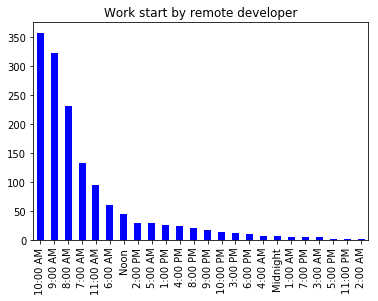

```python
blue_plot(start_time_remote_dev,"Work start by remote developer")
```

```python
remote_work_people['WorkStart'].value_counts()/df['WorkStart'].value_counts()
```

```
10:00 AM    0.105621
10:00 PM    0.218750
11:00 AM    0.123057
11:00 PM    0.041667
1:00 AM     0.235294
1:00 PM     0.157576
2:00 AM     0.083333
2:00 PM     0.181250
3:00 AM     0.222222
3:00 PM     0.184615
4:00 AM     0.225806
4:00 PM     0.255319
5:00 AM     0.304348
5:00 PM     0.071429
6:00 AM     0.131991
6:00 PM     0.149254
7:00 AM     0.103744
7:00 PM     0.105263
8:00 AM     0.086531
8:00 PM     0.253165
9:00 AM     0.089916
9:00 PM     0.307692
Midnight    0.304348
Noon        0.114286
Name: WorkStart, dtype: float64
```

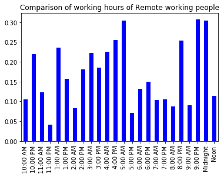

```python
comparison_remote_time=remote_work_people['WorkStart'].value_counts()/df['WorkStart'].value_counts()
blue_plot(comparison_remote_time,"Comparison of working hours of Remote working people")
```

So we see most of the remote workers prefer to start their work at 10am,9am and 8am but comparison to those who work full time rmote developer are in large no. who like to start their work at 5 am, 9 pm,10 pm and midnight But How many of them are profesional ?

```python
remote_work_people['Professional'].value_counts()
```

```
Professional developer                                  1546
Student                                                  173
Professional non-developer who sometimes writes code     169
Used to be a professional developer                       34
Name: Professional, dtype: int64
```

```python
remote_work_people['Professional'].value_counts()/remote_work_people.shape[0]
```

```
Professional developer                                  0.804370
Student                                                 0.090010
Professional non-developer who sometimes writes code    0.087929
Used to be a professional developer                     0.017690
Name: Professional, dtype: float64
```

Remote working people are mostly Professional developer that is about 80%